# Capstone Project - Bellabeat Case Study

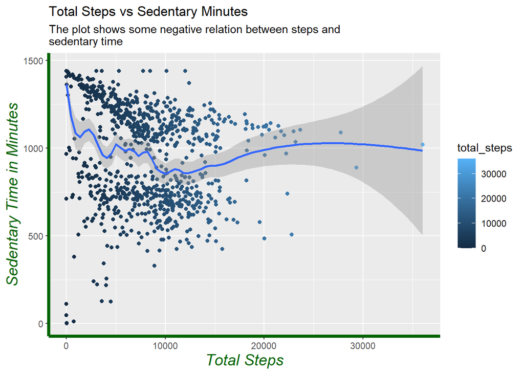

```r
# plotting all 33 id's to show relationship between total steps and sedentary minutes

activity1 %>% ggplot(aes(x=total_steps,y=sedentary_minutes,color = total_steps))+
  geom_point()+
  geom_smooth(span = 0.2)+
  labs(title = "Total Steps vs Sedentary Minutes",subtitle = "The plot shows some negative relation between steps and \nsedentary time")+
  xlab("Total Steps")+ylab("Sedentary Time in Minutes")+
  theme(axis.title = element_text(color = "dark green",face="italic",size = 15))+theme(axis.line = element_line(color = 'dark green', size = 1.5, linetype = 1))
```

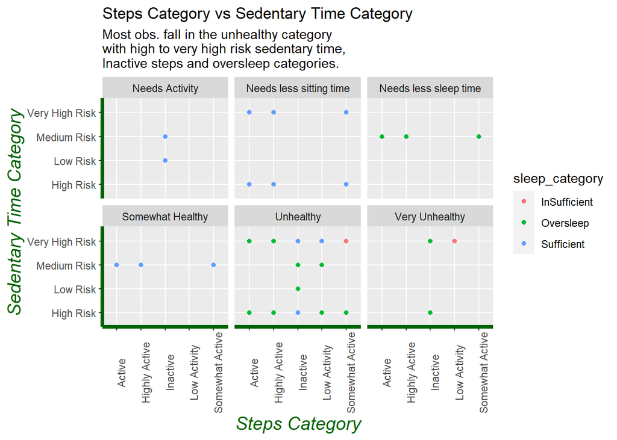

```r
# plotting steps,sleep,sedentary time for each lifestyle category

analysis12 %>% ggplot(aes(x=steps_category,y=sedentary_time_category,color=sleep_category))+
  geom_point()+
  facet_wrap(~Lifestyle_category)+
  labs(title = "Steps Category vs Sedentary Time Category",subtitle = "Most obs. fall in the unhealthy category \nwith high to very high risk sedentary time, \nInactive steps and oversleep categories.")+
  xlab("Steps Category")+ylab("Sedentary Time Category")+
  theme(axis.title = element_text(color = "dark green",face="italic",size = 15))+theme(axis.line = element_line(color = 'dark green', size = 1.5, linetype = 1))+
  theme(axis.text.x = element_text(angle = 90))
```

## **Act**:

**Recommendations**:

*Insight*: Only 18% of total users record 3 variables of health(Steps,Sleep,Weight) which is a very small number.

*Recommendation*: BellaBeat should encourage all its users to record all variables of health by explaining its importance, benefits of recording all health variables, thereby increasing usage of smart devices.

*Recommendation*: Marketing team should promote and advertise our products as a successful indicator of a persons lifestyle in terms of health and show what changes can one make to lead a healthy lifestyle, inform users about the ill effects of leading an unhealthy lifestyle and benefits of a healthy one.

The health variables to target for informing users are **STEPS,SLEEP TIME and SEDENTARY TIME**.

*Insight*: Weight and Heart rate are the least recorded health variables in terms of the number of id’s recording them.

*Recommendation*: Importance of these two health variables shall be explained to users specifically not recording them and encourage them to have them recorded.

*Insight*: There is a difference of **104280** steps between daily steps and hourly steps recorded and a difference of **13243** calories in daily and hourly calories recorded.

*Recommendation*: Reason behind this difference must be investigated, to see if there is a glitch and if there is one, utmost care must be taken to ensure there exists nothing of this sort in BellaBeat’s products.